# Extracting NASIS Rules/Evaluations

D.E. Beaudette and J. Nemecek

2020-03-03

```r
library(soilDB)
library(RODBC)
library(XML)
library(plyr)
library(data.tree)
library(digest)
library(jsonlite)
library(sharpshootR)
library(knitr)

# source local functions
source('local-functions.R')

# re-load cached data
# getAndCacheData()

# load cached data
load('cached-NASIS-data.Rda')
```

## Evaluations

### Evaluation Types

```r
kable(sort(table(evals$evaluationtype), decreasing = TRUE))
```

| Var1 | Freq |
| --- | --- |
| Crisp | 4306 |
| Sigmoid | 2317 |
| ArbitraryLinear | 1386 |
| ArbitraryCurve | 1330 |
| Linear | 587 |
| Beta | 96 |
| Trapezoid | 43 |
| IsNull | 36 |
| PI | 14 |
| Gauss | 8 |
| Triangle | 1 |

### Evaluation Curves

Sometimes the property min/max values are crazy, you can manually set plot limits with `xlim` argument.

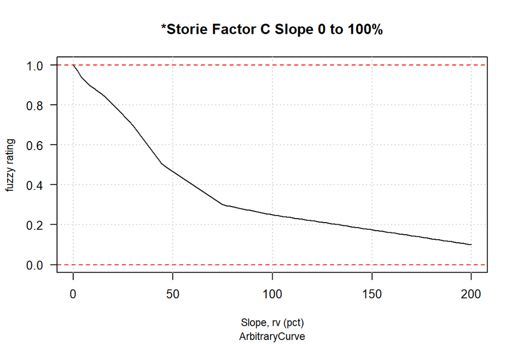

```r
# arbitrary curve:
e <- evals[evals$evalname == '*Storie Factor C Slope 0 to 100%', ]
plotEvaluation(e, xlim=c(0, 200))
```

```r
# get a function to describe the evaluation
s <- seq(0, 100, length.out = 10)
f <- extractEvalCurve(e)
cbind(domain=s, fuzzy.rating=f(s))
```

```
##          domain fuzzy.rating
##  [1,]   0.00000    1.0000000
##  [2,]  11.11111    0.8777778
##  [3,]  22.22222    0.7777778
##  [4,]  33.33333    0.6555556
##  [5,]  44.44444    0.5074074
##  [6,]  55.55556    0.4296296
##  [7,]  66.66667    0.3555556
##  [8,]  77.77778    0.2944444
##  [9,]  88.88889    0.2722222
## [10,] 100.00000    0.2500000
```

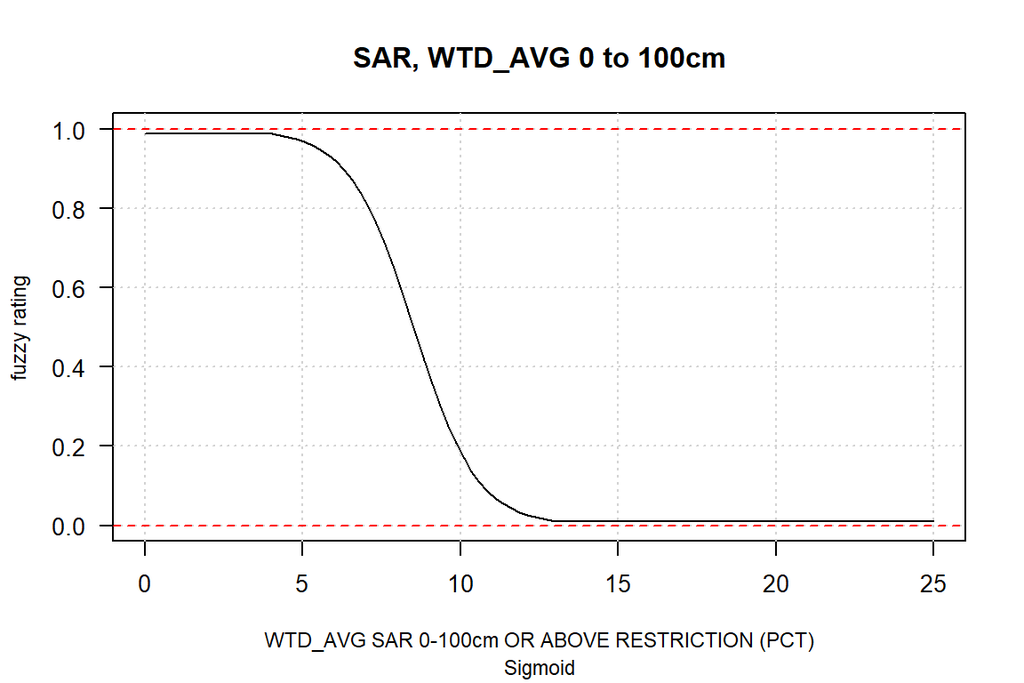

```r
## sigmoid:
e <- evals[evals$evalname == 'SAR, WTD_AVG 0 to 100cm', ]
plotEvaluation(e, xlim=c(0,25))
```

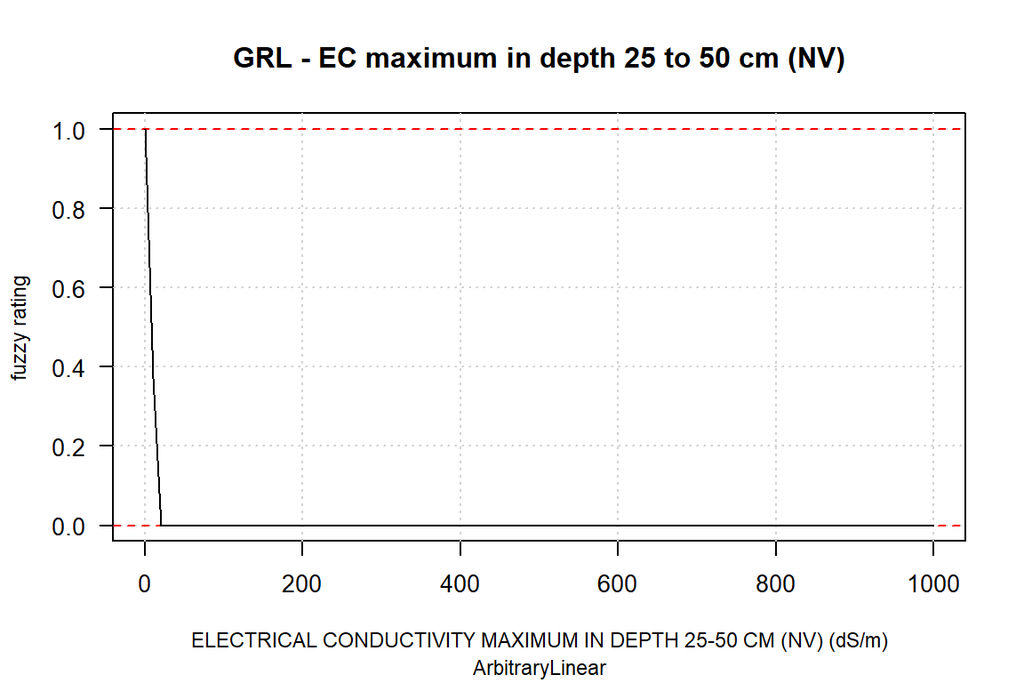

```r
# arbitrary linear
e <- evals[evals$evalname == 'GRL - EC maximum in depth 25 to 50 cm (NV)', ]
plotEvaluation(e, xlim=c(0, 1000))
```

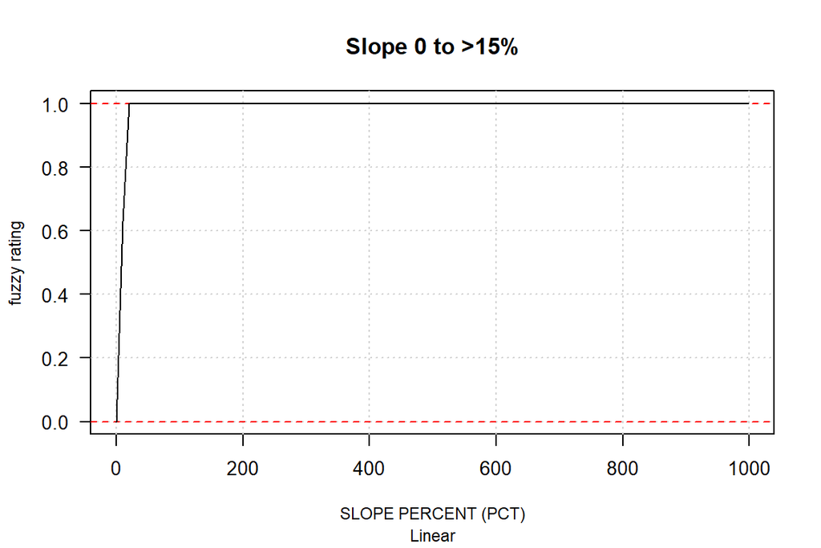

```r
# linear
e <- evals[evals$evalname == 'Slope 0 to >15%', ]
plotEvaluation(e)
```

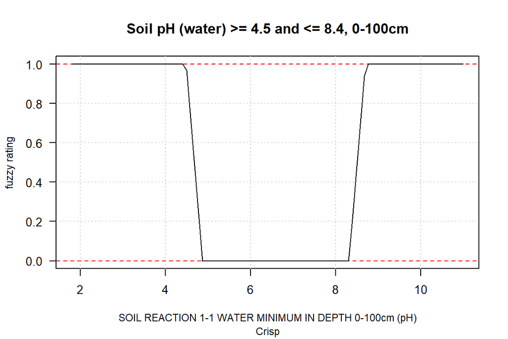

```r
# crisp:
e <- evals[evals$evalname == 'Soil pH (water) >= 4.5 and <= 8.4, 0-100cm', ]
plotEvaluation(e)
```

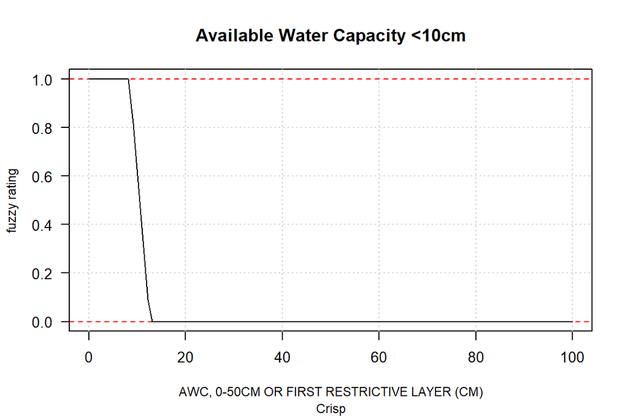

```r
e <- evals[evals$evalname == 'Available Water Capacity <10cm', ]
plotEvaluation(e)
```

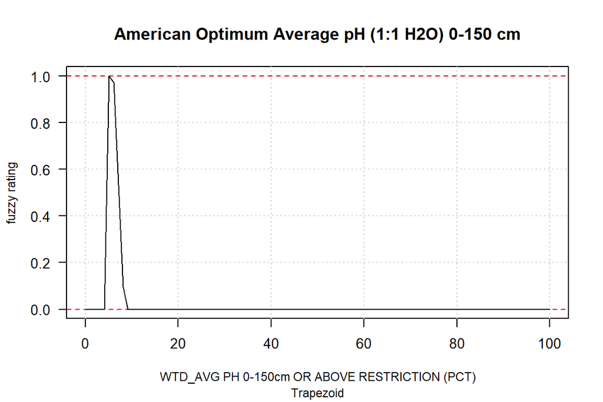

```r
## trapezoid
e <- evals[evals$evalname == 'American Optimum Average pH (1:1 H2O) 0-150 cm', ]
plotEvaluation(e)
```

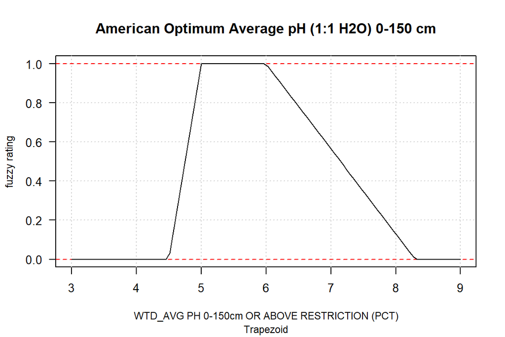

```r
plotEvaluation(e, xlim = c(3, 9))
```

```r
## doesn't work due to NA in min/max
## consider defaults of 0,1 ?
# e <- evals[evals$evalname == 'GRL-Frost Action = moderate', ]
# plotEvaluation(e)
```

Evaluate an arbitrary rule, with an arbitrary value. *NCCPI - pH 0-20cm (Corn and Soybeans)* and pH = 6.5

```r
e <- evals[evals$evalname == 'NCCPI - pH 0-20cm (Corn and Soybeans)', ]
extractEvalCurve(e)(6.5)
```

```
## [1] 0.9609756
```

## Rule Trees

- check a couple, RefId points to rows in rules or evaluation tables
- the dt$Do call links child sub-rules
- recursion is used to traverse to the deepest nodes, seems to work
- **caution:** don't run several times on the same object!
- increase limit argument to see the entire tree

```r
# just some random rule
y <- rules[rules$rulename == 'Dust PM10 and PM2.5 Generation', ]

dt <- parseRule(y)

# print intermediate results
print(dt, 'Type', 'Value', 'RefId', 'rule_refid', 'eval_refid', limit=25)
```

```
##                                   levelName     Type Value RefId rule_refid eval_refid
## 1 Dust PM10 and PM2.5 Generation
## 2  °--RuleHedge_de473ab5                    multiply   0.5
## 3      °--RuleOperator_0a397761              product
## 4          ¦--Dryness Index 0.5 to 3                       18448                 18448
## 5          °--RuleOperator_7025ab26              sum
## 6              ¦--Dust Due to Gypsum                       23659      23659
## 7              °--Dust Due to Silt and Clay                23661      23661
```

```r
# recusively splice-in sub-rules
dt$Do(traversal='pre-order', fun=linkSubRules)
# splice-in evaluation functions, if possible
dt$Do(traversal='pre-order', fun=linkEvaluationFunctions)

# print more attributes
options(width=300)
print(dt, 'Type', 'Value', 'RefId', 'rule_refid', 'eval_refid', 'evalType', limit=25)
```

```
##                                                                        levelName           Type Value RefId rule_refid eval_refid evalType
## 1  Dust PM10 and PM2.5 Generation
## 2   °--RuleHedge_de473ab5                                                              multiply   0.5
## 3       °--RuleOperator_0a397761                                                        product
## 4           ¦--Dryness Index 0.5 to 3                                                                 18448                 18448  Sigmoid
## 5           °--RuleOperator_7025ab26                                                        sum
## 6               ¦--Dust Due to Gypsum                                                                 23659      23659
## 7               ¦   °--RuleHedge_5c18cb73                                          not_null_and     0
## 8               ¦       °--Dust from Gypsum Content 2 to 15 Percent                                   18446                 18446  Sigmoid
## 9               °--Dust Due to Silt and Clay                                                          23661      23661
## 10                  °--RuleHedge_caf7e2e0                                        null_not_rated     0
## 11                      °--Dust from Silt and Clay Content 20 to 70 Percent Sand                      18447                 18447   Linear
```

```r
print(dt, 'Type', 'Value', 'evalType', 'propname', 'propiid', 'propuom', limit=25)
```

```
##                                                                        levelName           Type Value evalType                                               propname propiid propuom
## 1  Dust PM10 and PM2.5 Generation
## 2   °--RuleHedge_de473ab5                                                              multiply   0.5
## 3       °--RuleOperator_0a397761                                                        product
## 4           ¦--Dryness Index 0.5 to 3                                                                  Sigmoid                                          DRYNESS INDEX   15302     pct
## 5           °--RuleOperator_7025ab26                                                        sum
## 6               ¦--Dust Due to Gypsum
## 7               ¦   °--RuleHedge_5c18cb73                                          not_null_and     0
## 8               ¦       °--Dust from Gypsum Content 2 to 15 Percent                                    Sigmoid             WTD_AVG GYPSUM 0-50cm OR ABOVE RESTRICTION   15300     PCT
## 9               °--Dust Due to Silt and Clay
## 10                  °--RuleHedge_caf7e2e0                                        null_not_rated     0
## 11                      °--Dust from Silt and Clay Content 20 to 70 Percent Sand                        Linear WTD_AVG SAND CONTENT 0-50cm OR ABOVE RESTRICTION, NO O   15301     PCT
```

Frost Action.

```r
# idx <- grep('frost action', rules$rulename, ignore.case = TRUE)
# rules[idx, ]$rulename

y <- rules[rules$rulename == 'GRL-Frost Action = moderate', ]

dt <- parseRule(y)

# print intermediate results
print(dt, 'Type', 'Value', 'RefId', 'rule_refid', 'eval_refid', limit=25)
```

```
##                         levelName Type Value RefId rule_refid eval_refid
## 1 GRL-Frost Action = moderate       NA    NA               NA
## 2  °--GRL-Frost Action = moderate   NA    NA 19355         NA      19355
```

```r
# recusively splice-in sub-rules
dt$Do(traversal='pre-order', fun=linkSubRules)
# splice-in evaluation functions, if possible
dt$Do(traversal='pre-order', fun=linkEvaluationFunctions)

# print more attributes
options(width=300)
print(dt, 'Type', 'Value', 'RefId', 'rule_refid', 'eval_refid', 'evalType', limit=25)
```

```
##                         levelName Type Value RefId rule_refid eval_refid evalType
## 1 GRL-Frost Action = moderate       NA    NA               NA
## 2  °--GRL-Frost Action = moderate   NA    NA 19355         NA      19355    Crisp
```

```r
print(dt, 'Type', 'Value', 'evalType', 'propname', 'propiid', 'propuom', limit=25)
```

```
##                         levelName Type Value evalType         propname propiid propuom
## 1 GRL-Frost Action = moderate       NA    NA
## 2  °--GRL-Frost Action = moderate   NA    NA    Crisp GRL-FROST ACTION   10095
```

Get a table of unique evaluations, properties, and property IDs

```r
(ps <- getPropertySet(dt))
```

```
##                    evaluation         propname propiid
## 1 GRL-Frost Action = moderate GRL-FROST ACTION   10095
```

SVI (?)

```r
# idx <- grep('SVI', rules$rulename, ignore.case = TRUE)
# rules[idx, ]$rulename

y <- rules[rules$rulename == 'SVI - Leaching', ]

dt <- parseRule(y)

# print intermediate results
print(dt, 'Type', 'Value', 'RefId', 'rule_refid', 'eval_refid', limit=25)
```

```
##                levelName           Type Value RefId rule_refid eval_refid
## 1 SVI - Leaching                                            NA
## 2  °--RuleHedge_af74ec2c null_not_rated     0               NA
## 3      °--SVI - Leaching                      51364         NA      51364
```

```r
# recusively splice-in sub-rules
dt$Do(traversal='pre-order', fun=linkSubRules)
# splice-in evaluation functions, if possible
dt$Do(traversal='pre-order', fun=linkEvaluationFunctions)

# print more attributes
options(width=300)
print(dt, 'Type', 'Value', 'RefId', 'rule_refid', 'eval_refid', 'evalType', limit=25)
```

```
##                levelName           Type Value RefId rule_refid eval_refid        evalType
## 1 SVI - Leaching                                            NA
## 2  °--RuleHedge_af74ec2c null_not_rated     0               NA
## 3      °--SVI - Leaching                      51364         NA      51364 ArbitraryLinear
```

```r
print(dt, 'Type', 'Value', 'evalType', 'propname', 'propiid', 'propuom', limit=25)
```

```
##                levelName           Type Value        evalType                                 propname propiid propuom
## 1 SVI - Leaching
## 2  °--RuleHedge_af74ec2c null_not_rated     0
## 3      °--SVI - Leaching                      ArbitraryLinear SVI - Leaching Risk with RF modification   41695
```

Get a table of unique evaluations, properties, and property IDs

```r
(ps <- getPropertySet(dt))
```

```
##       evaluation                                 propname propiid
## 1 SVI - Leaching SVI - Leaching Risk with RF modification   41695
```

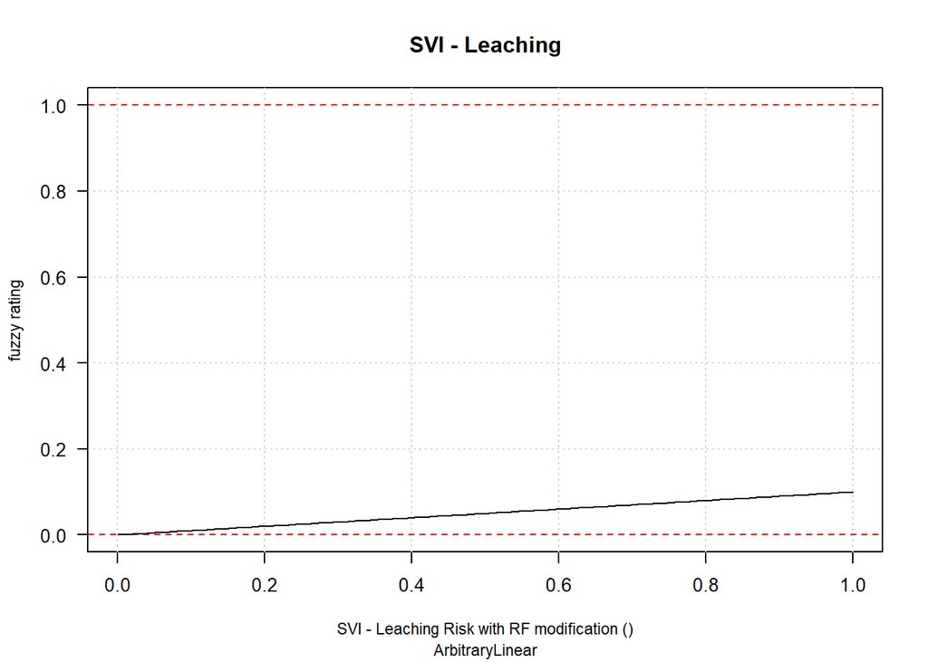

```r
e <- evals[evals$evalname == 'SVI - Leaching', ]
plotEvaluation(e)
```

### Properties via NASIS WebReport

Experimental and subject to change. Can specify multiple componet records but only a single property.

```r
url <- 'https://nasis.sc.egov.usda.gov/NasisReportsWebSite/limsreport.aspx?report_name=WEB-PROPERY-COMPONENT_property'

# prop_id: property ID (10244 = AWC, 0-50CM OR FIRST RESTRICTIVE LAYER)
# cokey: component record ID, can be a comma-delim list
args <- list(prop_id='10244', cokey='1842387')

res <- parseWebReport(url, args, index=1)
kable(res)
```

| coiid | comp_name | comp_pct | rv |
| --- | --- | --- | --- |
| 1842387 | Bonanza | 54 | 5 |

More useful, connect the property back to the name of the property.

```r
props <- lookupProperties(unique(ps$propiid), coiid='1842387')
```

```r
# join with properties
z <- join(ps, props, by='propiid', type='left')

kable(z)
```

| evaluation | propname | propiid | coiid | comp_name | comp_pct | rv |
| --- | --- | --- | --- | --- | --- | --- |
| SVI - Leaching | SVI - Leaching Risk with RF modification | 41695 | 1842387 | Bonanza | 54 | 3 |

### More Examples

**WLF-Soil Suitability - Karner Blue Butterfly**

```r
y <- rules[rules$rulename == 'WLF-Soil Suitability - Karner Blue Butterfly (WI)', ]
dt <- parseRule(y)
dt$Do(traversal='pre-order', fun=linkSubRules)
dt$Do(traversal='pre-order', fun=linkEvaluationFunctions)
print(dt, 'Type', 'Value', 'RefId', 'rule_refid', 'eval_refid', 'evalType', limit=25)
```

```
##                                                                   levelName           Type Value RefId rule_refid eval_refid       evalType
## 1  WLF-Soil Suitability - Karner Blue Butterfly (WI)
## 2   °--RuleOperator_5a212216                                                           sum
## 3       ¦--KARNER-WTAVG  pH 0-25 CM                                                              54912      54912
## 4       ¦   °--RuleHedge_35708357                                                 multiply  0.40
## 5       ¦       °--RuleHedge_365b55e7                                         not_null_and     0
## 6       ¦           °--SQL-WTAVG pH 0-25 CM                                                      58995                 58995 ArbitraryCurve
## 7       ¦--KSAT MINIMUM IN DEPTH TO 50 cm  or above restriction                                  54909      54909
## 8       ¦   °--RuleHedge_bf1a17d3                                                 multiply   0.3
## 9       ¦       °--RuleHedge_320dab32                                         not_null_and     0
## 10      ¦           °--KSAT MINIMUM IN DEPTH TO 50 cm  or above restriction                      58993                 58993        Sigmoid
## 11      ¦--KARNER-DEPTH TO HIGH WATER TABLE, Growing Season MIN                                  54910      54910
## 12      ¦   °--RuleHedge_6a3ca5bc                                                 multiply  0.20
## 13      ¦       °--RuleHedge_f61186b5                                         not_null_and     0
## 14      ¦           °--KARNER-DEPTH TO HIGH WATER TABLE, Growing Season MIN                      58994                 58994 ArbitraryCurve
## 15      ¦--KARNER-AWS, 0-50CM OR FIRST RESTRICTIVE LAYER                                         54911      54911
## 16      ¦   °--RuleHedge_53c64069                                                 multiply  0.10
## 17      ¦       °--RuleHedge_030dc816                                         not_null_and     0
## 18      ¦           °--KARNER-AWS, 0-50CM OR FIRST RESTRICTIVE LAYER                             58992                 58992        Sigmoid
## 19      °--WICCPI - Interpretable Component                                                      54894      54894
## 20          °--RuleHedge_f342e93d                                           null_not_rated     0
## 21              °--WICCPI - Interpretable Component                                              58981                 58981          Crisp
```

```r
ps <- getPropertySet(dt)
kable(ps)
```

| evaluation | propname | propiid |
| --- | --- | --- |
| SQL-WTAVG pH 0-25 CM | SQL-WTAVG pH 0-25 CM | 53921 |
| KSAT MINIMUM IN DEPTH TO 50 cm or above restriction | SQL-KSAT MINIMUM IN DEPTH TO 50 cm or above restriction | 47060 |
| KARNER-DEPTH TO HIGH WATER TABLE, Growing Season MIN | SQL- DEPTH TO HIGH WATER TABLE, Growing Season MIN | 53917 |
| KARNER-AWS, 0-50CM OR FIRST RESTRICTIVE LAYER | SQL-AWS, 0-50CM OR FIRST RESTRICTIVE LAYER | 47032 |
| WICCPI - Interpretable Component | INTERPRETABLE COMPONENT | 15327 |

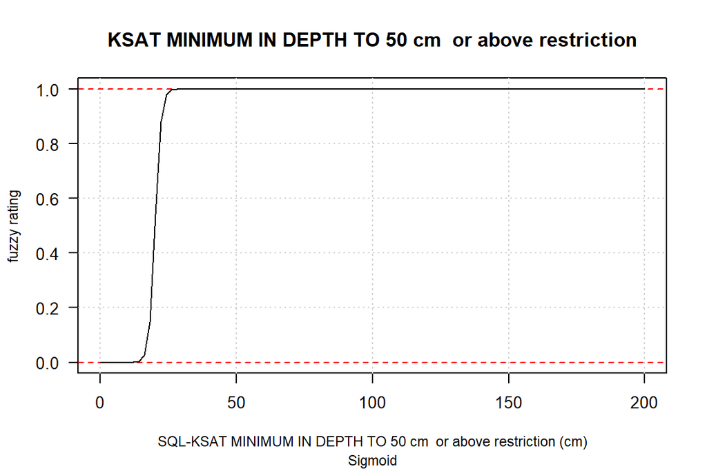

```r
e <- evals[evals$evalname == 'KSAT MINIMUM IN DEPTH TO 50 cm  or above restriction', ]
plotEvaluation(e, xlim=c(0, 200))
```

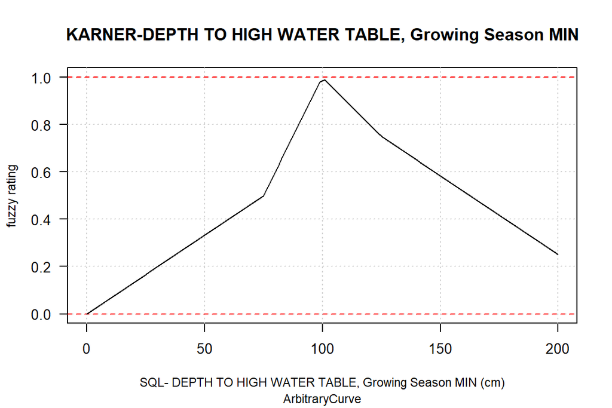

```r
e <- evals[evals$evalname == 'KARNER-DEPTH TO HIGH WATER TABLE, Growing Season MIN', ]
plotEvaluation(e, xlim=c(0, 200))
```

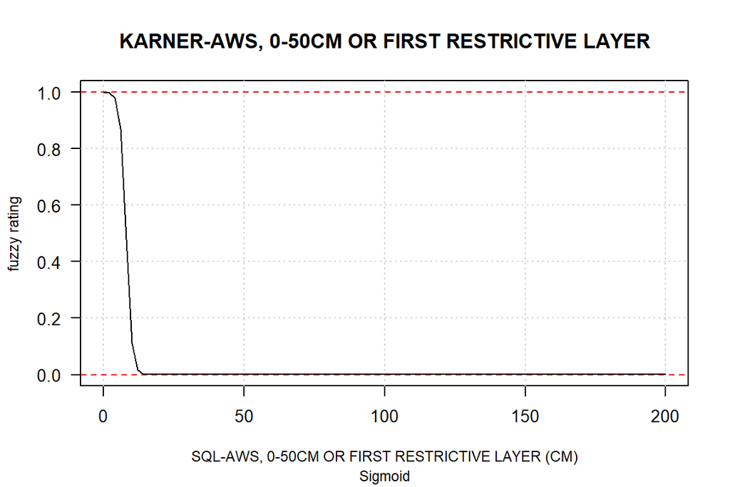

```r
e <- evals[evals$evalname == 'KARNER-AWS, 0-50CM OR FIRST RESTRICTIVE LAYER', ]
plotEvaluation(e, xlim=c(0, 200))
```

```r
## dangit, haven't implemented this kind of evaluation yet
# e <- evals[evals$evalname == 'WICCPI - Interpretable Component', ]
# plotEvaluation(e, xlim=c(0, 200))
```

**California Revised Storie Index**

```r
y <- rules[rules$rulename == 'AGR - California Revised Storie Index (CA)', ]
dt <- parseRule(y)
dt$Do(traversal='pre-order', fun=linkSubRules)
dt$Do(traversal='pre-order', fun=linkEvaluationFunctions)
print(dt, 'Type', 'Value', 'RefId', 'rule_refid', 'eval_refid', 'evalType', limit=25)
```

```
##                                                                              levelName         Type Value RefId rule_refid eval_refid       evalType
## 1  AGR - California Revised Storie Index (CA)
## 2   °--RuleOperator_31a1eb65                                                                product
## 3       ¦--*Storie Factor A Not Rated Soil Orders rev                                                     49446      49446
## 4       ¦   °--RuleHedge_1193d3c1                                                           null_or     0
## 5       ¦       °--*Storie Factor A Pedon Group not rated taxonomy rev                                    50481                 50481          Crisp
## 6       ¦--*Storie Factor A                                                                               15976      15976
## 7       ¦   °--RuleOperator_01948bb8                                                             or
## 8       ¦       ¦--*Storie Factor A Profile Group 1 rev                                                   49448      49448
## 9       ¦       ¦   °--RuleOperator_a72ba798                                                    and
## 10      ¦       ¦       ¦--RuleOperator_b267bf8e                                              times
## 11      ¦       ¦       ¦   ¦--*Storie Factor A Profile Group 1 and 2 fuzzy depth                         15967      15967
## 12      ¦       ¦       ¦   ¦   °--RuleHedge_7fad1a79                                  not_null_and     0
## 13      ¦       ¦       ¦   ¦       °--*Storie Factor A Pedon Group 1 and 2 soil depth                    12916                 12916 ArbitraryCurve
## 14      ¦       ¦       ¦   °--*Storie Factor A Profile Group 1 taxonomy rev                              49447      49447
## 15      ¦       ¦       ¦       °--RuleOperator_4d1fdd8f                                         or
## 16      ¦       ¦       ¦           ¦--RuleHedge_44b2d8f3                              not_null_and     0
## 17      ¦       ¦       ¦           ¦   °--*Storie Factor A Pedon Group 1 suborders                       12914                 12914          Crisp
## 18      ¦       ¦       ¦           ¦--RuleHedge_f2a5b4ba                              not_null_and     0
## 19      ¦       ¦       ¦           ¦   °--*Storie Factor A Pedon Group 1 great groups                    12915                 12915          Crisp
## 20      ¦       ¦       ¦           °--RuleHedge_25e606a5                              not_null_and     0
## 21      ¦       ¦       ¦               °--*Storie Factor A Pedon Group 1 subgroups                       13092                 13092          Crisp
## 22      ¦       ¦       °--RuleHedge_ea4b1839                                                   not     0
## 23      ¦       ¦           °--*Storie Factor A Profile Group 7,8,9 landform                              15974      15974
## 24      ¦       ¦               °--RuleHedge_608f03c8                                  not_null_and     0
## 25      ¦       ¦                   °--... 1 nodes w/ 0 sub
## 26      ¦       °--... 5 nodes w/ 78 sub
## 27      °--... 5 nodes w/ 223 sub
```

```r
options(width=80)
ps <- getPropertySet(dt)
unique(ps$propname)
```

```
##  [1] "TAXONOMIC ORDER"
##  [2] "*Storie depth to first restriction for Profile Group 1-3"
##  [3] "TAXONOMIC SUBORDER"
##  [4] "TAXONOMIC GREAT GROUP"
##  [5] "TAXONOMIC SUBGROUP"
##  [6] "*Storie landforms in hills and mountains of California"
##  [7] "*Storie where at least one cdfkind = abrupt textural change"
##  [8] "Component restrictions"
##  [9] "*Storie depth to pan for Profile Group 5"
## [10] "*Storie depth to featknd abrupt tex change Profile Group 4/6"
## [11] "*Storie depth to reskind abrupt tex change Profile Grp 4/6"
## [12] "*Storie depth to hard bedrock/petro* for Profile Grp 7/8/9"
## [13] "*Storie depth to soft bedrock or densics for Profile Grp 7-9"
## [14] "*Storie texture score - first horizon below duff"
## [15] "ROCK FRAG VOLUME IN DEPTH 0-25 cm OR RESTRICTION"
## [16] "Slope, rv"
## [17] "EC MAXIMUM IN DEPTH 0-25 CM BELOW DUFF"
## [18] "SAR MAXIMUM IN DEPTH 0-25 CM BELOW DUFF"
## [19] "pH MINIMUM IN DEPTH 0-25 CM BELOW DUFF"
## [20] "pH MAXIMUM IN DEPTH 0-25 CM BELOW DUFF"
## [21] "GRL-DRAINAGE CLASS"
## [22] "**Storie component local phase is drained"
## [23] "**Storie component local phase is partially drained"
## [24] "*Storie ponding interaction max in growing season"
## [25] "FLOODING FREQUENCY (Maximum Frequency)"
## [26] "*Storie flooding interaction max in growing season"
## [27] "Erosion Class in component table"
## [28] "*Storie near surface wetness rv depth in growing season"
## [29] "*Storie temperature regime score"
```

**NCCPI Version 3.0**

```r
y <- rules[rules$rulename == 'NCCPI - National Commodity Crop Productivity Index (Ver 3.0)', ]
dt <- parseRule(y)
dt$Do(traversal='pre-order', fun=linkSubRules)
dt$Do(traversal='pre-order', fun=linkEvaluationFunctions)

options(width=500, max.print = 1e6)
sink(file = 'examples/nccpi-full-tree.txt')
print(dt, 'Type', 'Value', 'RefId', 'rule_refid', 'eval_refid', 'evalType', 'propname', 'propiid', limit=NULL)
sink()

options(max.print=1000, width=80)

# save properties and IDs to CSV
ps <- getPropertySet(dt)
write.csv(ps, file='examples/nccpi-properties.csv', row.names = FALSE)

# flatten tree to data.frame and save to CSV
d <- ToDataFrameTable(dt, 'name', 'Type', 'Value', 'RefId', 'rule_refid', 'eval_refid', 'evalType', 'propname', 'propiid')
write.csv(unique(d), file='examples/nccpi-table-representation.csv', row.names = FALSE)
```

**Commodity Crop Productivity Index (Corn) (WI)**

```r
y <- rules[rules$rulename == 'Commodity Crop Productivity Index (Corn) (WI)', ]
dt <- parseRule(y)
dt$Do(traversal='pre-order', fun=linkSubRules)
dt$Do(traversal='pre-order', fun=linkEvaluationFunctions)

options(width=500, max.print = 1e6)
sink(file = 'examples/CCPI-WI-full-tree.txt')
print(dt, 'Type', 'Value', 'RefId', 'rule_refid', 'eval_refid', 'evalType', 'propname', 'propiid', limit=NULL)
sink()

options(max.print=1000, width=200)

ps <- getPropertySet(dt)
write.csv(unique(ps), file='examples/CCPI-WI-properties.csv', row.names = FALSE)

d <- ToDataFrameTable(dt, 'name', 'Type', 'Value', 'RefId', 'rule_refid', 'eval_refid', 'evalType', 'propname', 'propiid')
write.csv(unique(d), file='examples/CCPI-WI-table-representation.csv', row.names = FALSE)
```

Get all properties that this interpretation requires, for a given component. Runtime: 1 minute. Some requests result in an error, due to request time-out or SSL errors--why? Only happens some times.

```r
(props <- lookupProperties(unique(ps$propiid), coiid='1842387'))

# join with properties
z <- join(ps, props, by='propiid', type='left')
```

```r
y <- rules[rules$rulename == 'Commodity Crop Productivity Index (Corn) (WI)', ]
dt <- parseRule(y)
dt$Do(traversal='pre-order', fun=linkSubRules)
dt$Do(traversal='pre-order', fun=linkEvaluationFunctions)
print(dt, 'Type', 'Value', 'RefId', 'rule_refid', 'eval_refid', 'evalType', limit=25)
```

```
##                                                           levelName
## 1  Commodity Crop Productivity Index (Corn) (WI)
## 2   °--WICCPI - Wisconsin Commodity Corn Production
## 3       °--RuleOperator_e43a1351
## 4           ¦--WICCPI - OM Subrule
## 5           ¦   °--RuleOperator_75d1fcc3
## 6           ¦       ¦--RuleHedge_2771d4a5
## 7           ¦       ¦   °--RuleHedge_f100a187
## 8           ¦       ¦       °--WICCPI - OM 0-20cm
## 9           ¦       °--RuleHedge_d16882a6
## 10          ¦           °--RuleHedge_6927e4f4
## 11          ¦               °--WICCPI - OM 20-100cm
## 12          ¦--WICCPI - CEC Subrule
## 13          ¦   °--RuleOperator_f347e267
## 14          ¦       ¦--RuleHedge_758fdaa5
```

[output cut: 39 more lines]

```r
y <- rules[rules$rulename == 'DHS - Catastrophic Mortality, Large Animal Disposal, Pit', ]
dt <- parseRule(y)
dt$Do(traversal='pre-order', fun=linkSubRules)
dt$Do(traversal='pre-order', fun=linkEvaluationFunctions)
print(dt, 'Type', 'Value', 'RefId', 'rule_refid', 'eval_refid', 'evalType', limit=25)
```

```
##                                                              levelName
## 1  DHS - Catastrophic Mortality, Large Animal Disposal, Pit
## 2   °--RuleOperator_eadd904b
## 3       ¦--Permafrost
## 4       ¦   °--RuleOperator_dd37796c
## 5       ¦       ¦--RuleHedge_ea3fa12b
## 6       ¦       ¦   °--Permafrost (Consolidated) InLieuOf
## 7       ¦       ¦--RuleHedge_296e9a0c
## 8       ¦       ¦   °--Texture Modifier (Permanently Frozen)
## 9       ¦       °--RuleHedge_f6fc035d
## 10      ¦           °--Shallow to Permafrost (50 to 100cm (20 to 40"))
## 11      ¦--Ponded > 4 hours, Max
## 12      ¦   °--RuleOperator_9fea508b
## 13      ¦       ¦--RuleHedge_278a7dc1
## 14      ¦       ¦   °--RuleHedge_1a7cc2f2
```

[output cut: 41 more lines]

```r
# this one has a single RuleEvaluation: RefId points to rows in evals table
y <- rules[rules$rulename == 'Clay %, in surface - MO2', ]
dt <- parseRule(y)
dt$Do(traversal='pre-order', fun=linkSubRules)
dt$Do(traversal='pre-order', fun=linkEvaluationFunctions)
print(dt, 'Type', 'Value', 'RefId', 'rule_refid', 'eval_refid', 'evalType', limit=25)
```

```
##                                    levelName         Type Value RefId
## 1 Clay %, in surface - MO2
## 2  °--RuleHedge_85c74e0f                     not_null_and     0
## 3      °--Clay % >=40% at the surface, crisp                    11393
##   rule_refid eval_refid evalType
## 1         NA
## 2         NA
## 3         NA      11393    Crisp
```

## Conversion to JSON and D3 Vizualization

The objects can't have evaluation functions attached

```r
y <- rules[rules$rulename == 'Commodity Crop Productivity Index (Corn) (WI)', ]
dt <- parseRule(y)
dt$Do(traversal='pre-order', fun=linkSubRules)
dt$Do(traversal='pre-order', fun=linkEvaluationFunctions)

# prep for use in D3
# note arguments for D3 JSON compatibility
dt.list <- ToListExplicit(dt, unname = TRUE, nameName = "name", childrenName = "children")
dt.json <- toJSON(dt.list, pretty = TRUE, auto_unbox = TRUE, force=TRUE)

# save local copy of JSON
cat(dt.json, file='D3/dt.json')


# test with:
# "C:\Program Files (x86)\PYTHON27\ArcGIS10.1\python.exe" -m SimpleHTTPServer
```